# IMC - TD n°1

## Quantiles

```r
quantile(x = mpg$hwy)
```

```
  0%  25%  50%  75% 100%
  12   18   24   27   44
```

```r
quantile(x = mpg$hwy, probs = 0.3)
```

```
30%
 19
```

```r
quantile(x = mpg$hwy, probs = 0.99)
```

```
  99%
39.68
```

Les voitures de l’échantillon ont une autonomie entre 12 et 44 miles par galons, un quart moins de 18 mpg, une moitié moins que 24 mpg et trois quart moins de 27 mpg.

Boîte à moustache :

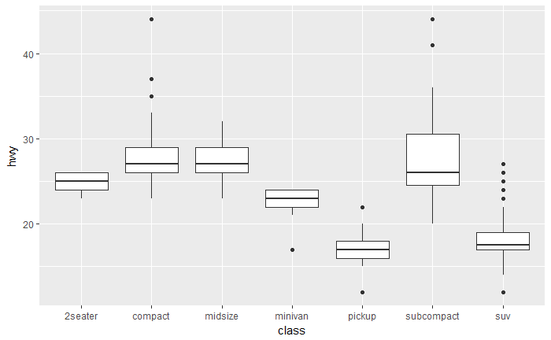

```r
work <- ggplot(data = mpg) + geom_boxplot(aes(x = class, y = hwy))
plot(work)
```

**Correction :** On peut également utiliser l’affichage `geom_violin` :

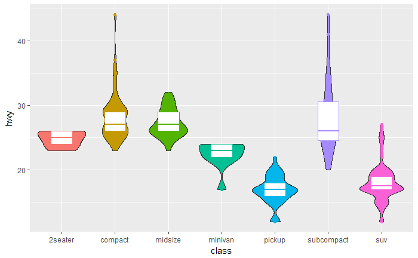

```r
work <- ggplot(data = mpg) + geom_violin(aes(x = class, fill = class, y = hwy)) + geom_boxplot(aes(x = class, y = hwy, colour = class), width = 0.4) + theme(legend.position = "none")
plot(work)
```

### Caractéristiques numériques

```r
for (carac in c("displ", "year", "cyl", "cty", "hwy")) {
  cat(paste(carac,":\n"))
  cat(paste("\t median:", median(mpg[[carac]]),"\n"))
  cat(paste("\t mean:", mean(mpg[[carac]]),"\n"))
  cat(paste("\t Inter-quartile range:", IQR(mpg[[carac]]),"\n"))
  cat(paste("\t Standard deviation:", sd(mpg[[carac]]),"\n"))
}
```

```
displ :
     median: 3.3
     mean: 3.47179487179487
     Inter-quartile range: 2.2
     Standard deviation: 1.29195903108393
year :
     median: 2003.5
     mean: 2003.5
     Inter-quartile range: 9
     Standard deviation: 4.50964631332044
cyl :
     median: 6
     mean: 5.88888888888889
     Inter-quartile range: 4
     Standard deviation: 1.61153448468429
cty :
     median: 17
     mean: 16.8589743589744
     Inter-quartile range: 5
     Standard deviation: 4.2559456788894
hwy :
     median: 24
     mean: 23.4401709401709
     Inter-quartile range: 9
     Standard deviation: 5.95464344116645
```

**Correction :** On peut églament sélectionner des données par l’opérateur `%>%` qui est une sorte de pipe. Par exemple :

```r
mpg.quanti = mpg %>% select( displ, year, cyl, cty, hwy)
data.frame(
  median = apply (mpg.quanti, MARGIN = 2, median),
  mean = apply (mpg.quanti, MARGIN = 2, mean),
  min = apply (mpg.quanti, MARGIN = 2, min),
  max = apply (mpg.quanti, MARGIN = 2, max),
  IQR = apply (mpg.quanti, MARGIN = 2, IQR),
  sd = apply (mpg.quanti, MARGIN = 2, sd)
)
```

|  | median | mean | min | max | IQR | sd |
| --- | --- | --- | --- | --- | --- | --- |
| displ | 3.3 | 3.471795 | 1.6 | 7 | 2.2 | 1.291959 |
| year | 2003.5 | 2003.500000 | 1999.0 | 2008 | 9.0 | 4.509646 |
| cyl | 6.0 | 5.888889 | 4.0 | 8 | 4.0 | 1.611534 |
| cty | 17.0 | 16.858974 | 9.0 | 35 | 5.0 | 4.255946 |
| hwy | 24.0 | 23.440171 | 12.0 | 44 | 9.0 | 5.954643 |

### Variables qualitatives

Les variables qualitatives nominales sont `manufacturer`, `model`, `drv` (on peut supposer que 4x4$>$2 roues motrices, mais il est impossible d’ordonner traction et propulsion) `trans`, `fl` et `class`. Il n’y a donc aucune variable qualitative ordinale.

**Correction :** on peut considérer que `displ` et `cyl` sont des variables qualitatives ordinales car elles sont à valeurs discrètes.

```r
work <- ggplot(mpg) + geom_histogram(aes(x=class, fill=drv), stat="count")
```

```
Ignoring unknown parameters: binwidth, bins, pad
```

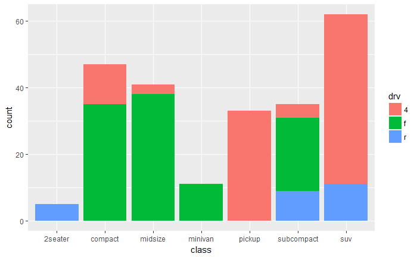

```r
plot(work)
```

On remaque que les 4x4 sont principalement des pickup et des SUV (logique), que les voitres à deux sièges sont toutes à propulsion, qu’aucun SUV n’est en tractions, aucun minivan n’est à quatre roues motrices, que la propulsion n’est présente que sur les voitures à deux sièges, les SUV et les subcompact, enfin que la traction prime sur les 4x4 pour les autres classes de voitures.

# Statistique descriptive bidimensionnelle

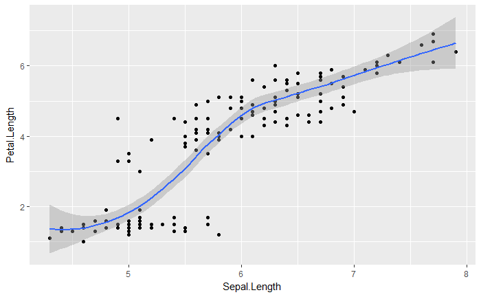

```r
work <- ggplot(data = iris) + geom_point(aes(x = Sepal.Length, y = Petal.Length)) +  geom_smooth(aes(x = Sepal.Length, y = Petal.Length))
plot(work)
```

```r
iter <- c("displ", "year", "cyl", "cty", "hwy")
for (carac in 1:4) {
  for (carac2 in (carac+1):5) {
    cat(paste("Correlation of ", iter[carac], " and ", iter[carac2], ": ", sep=""))
    cat(paste(cor(mpg[[iter[carac]]],mpg[[iter[carac2]]]),"\n"))
  }
}
```

```
Correlation of displ and year: 0.147842816450203
Correlation of displ and cyl: 0.93022710241985
Correlation of displ and cty: -0.798523968934855
Correlation of displ and hwy: -0.766020020886467
Correlation of year and cyl: 0.122245347435524
Correlation of year and cty: -0.0372322908599655
Correlation of year and hwy: 0.00215764307663203
Correlation of cyl and cty: -0.805771408267527
Correlation of cyl and hwy: -0.761912353897195
Correlation of cty and hwy: 0.955915913649572
```

On peut par exemple choisir deux caractéristiques, de préférence peu corrélées, et représenter un nuage de point des autres caractéristique représentant le coefficient de corrélation avec les deux variables choisies. Par exemple, pour `displ` et `year`, on obtient :

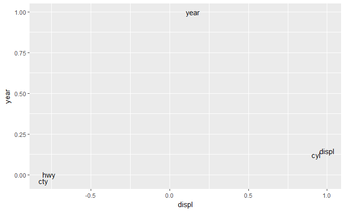

```r
iter <- c("displ", "year", "cyl", "cty", "hwy")
corr = data.frame(row.names = iter)
for (carac1 in iter) {
  vect <- c()
  for (carac2 in iter) {
    vect <- c(vect, cor(mpg[[carac1]],mpg[[carac2]]))
  }
  corr[[carac1]]=vect
}
work <- ggplot(data = corr) + geom_text(aes(x = displ, y = year, label = iter))
plot(work)
```

**Correction :** On peut utiliser une heatmap pour représenter ces corrélations (cf ecampus). On ne peut pas utiliser directment une `data.frame` car il faut un `tidy_dataset`. On peut transformer un `data.frame` en `tidy_dataset` par la fonction `gather`.

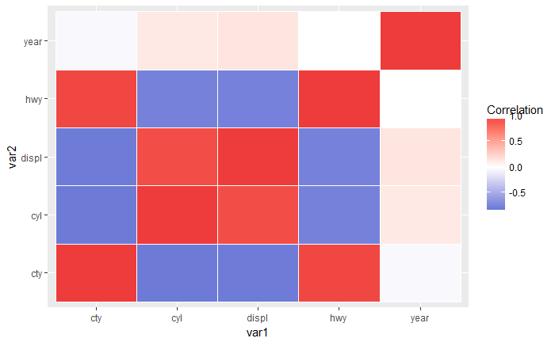

```r
corr2 = rownames_to_column(df = corr, var = "var1")
corr2.g = corr2 %>% gather(key = var2, value = Correlation, -var1, displ, year, cyl, cty, hwy)
work <- ggplot(data = corr2.g) + geom_tile( aes(x = var1, y = var2, fill = Correlation), color = "white") + scale_fill_gradient2(low = "royalblue3", mid = "white", high = "brown2")
plot(work)
```